# Walktrap with single community

john flournoy

The walktrap algorithm is a popular method of community-detection or cluster analysis in social network and correlational network data. Especially in psychological data, a reasonable hypothesis to be tested is simply whether or not clusters are detected. Detection of clusters are taken of evidence for their existence, and then membership is interpretted in light of the substantive goals of the investigation. If no clusters are detected, then interpretation of membership becomes moot. Therefore, the null hypothesis of primary interest is that there are no true clusters. In correlational network analysis, whether the correlation matrix expresses associations between measured variables or individual profiles, this null is quite reasonable as it instantiates the broad philisophical view of continuous variation without taxanomic differences. In the case of profile correlatoins, the existence of taxanomic separation between groups of people is especially controversial (examining clustering of variables is bread-and-butter psychometrics, though not without its own controversy).

I was curious to see how the walktrap algorithm performed under the null hypothesis of a single community. To investigate, I define generative population correlation matrices with identical correlations among all nodes. This ensures that each node is connected to every other node with equal weight. Since a community is defined by the relative densitity of connections between nodes within the same community as without, this seems to me a fairly straightforward and simple way to define a network strucutre with a single community. Another possibility, not yet investigated, is connecting each node to just two others such that all nodes are connected (a ring graph). There are other topologies as well, but I think the graph I use to generate is especially reasonable for the kinds of correlational networks we might observe in psychology (e.g., the ring graph seems a poor choice because it’s unrealistic to think that some variable would be correlated with just two others, and not at all to the remaining, or that some person would be similar in their personality profile to two other people but not at all to everyone else).

First, importantly, walktrap *is* capable of returing a single community under at least one condition (a perfectly estimated correlation network with one community as described above):

```r
sigma_cor <- diag(100)
sigma_cor[upper.tri(sigma_cor)] <- .3
sigma_cor[lower.tri(sigma_cor)] <- .3

agraph <- igraph::graph_from_adjacency_matrix(sigma_cor, mode = 'undirected', weighted = T, diag = F)
wtc <- igraph::walktrap.community(agraph)
length(wtc)
```

```
## [1] 1
```

```r
igraph::sizes(wtc)
```

```
## Community sizes
##   1
## 100
```

The real question is whether it can do so on noisy data.

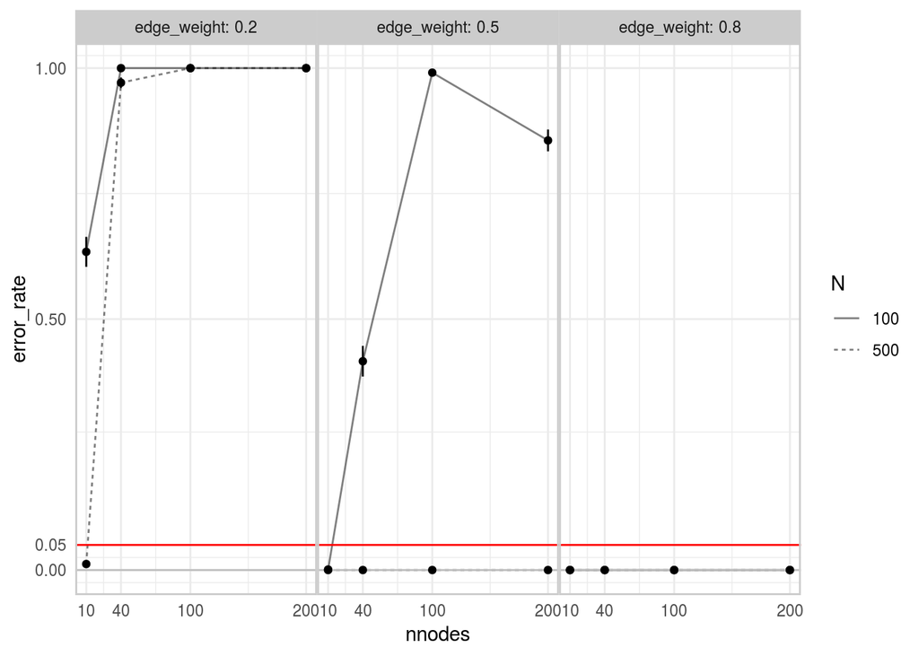

```r
library(igraph)
library(parallel)

count_coms <- function(nnodes = 100,
                                edge_weight = .3,
                                N = 100
){
  sigma_cor <- diag(nnodes)
  sigma_cor[upper.tri(sigma_cor)] <- edge_weight
  sigma_cor[lower.tri(sigma_cor)] <- edge_weight

  adf <- MASS::mvrnorm(n = N, Sigma = sigma_cor, mu = rep(0, nnodes))
  obs_cor_mat <- cor(adf)

  agraph <- igraph::graph_from_adjacency_matrix(obs_cor_mat, mode = 'undirected', weighted = T, diag = F)
  wtc <- igraph::walktrap.community(agraph)
  ncom <- length(wtc)
  return(ncom)
}
stderr.prop <- function(p, n){
  sqrt( p*(1 - p) / n )
}

nnodes <- c(10, 40, 100, 200)
replicates_df <- expand.grid(nnodes = nnodes, edge_weight = c(.2, .5, .8), N = c(100,500))

library(parallel)
simulated_rez <- parallel::mclapply(1:dim(replicates_df)[1], function(i){
  com_sizes <- replicate(1e3, expr = count_coms(nnodes = replicates_df$nnodes[i],
                                                edge_weight = replicates_df$edge_weight[i],
                                                N = replicates_df$N[i]))
  return(data.frame(
    nnodes = replicates_df$nnodes[i],
    edge_weight = replicates_df$edge_weight[i],
    N = replicates_df$N[i],
    size = com_sizes))
}, mc.cores = 4)

simulated_rez_df <- dplyr::bind_rows(simulated_rez) %>%
  dplyr::mutate(single_comm_detected = size == 1 | size == nnodes)

summary_df <- dplyr::summarize(dplyr::group_by(simulated_rez_df, nnodes, edge_weight, N),
                               error_rate = mean(!single_comm_detected),
                               se = stderr.prop(error_rate, dplyr::n()),
                               ci.u = error_rate + 1.96*se,
                               ci.l = error_rate - 1.96*se)
library(ggplot2)
bordergray <- '#cccccc'
ggplot(dplyr::mutate(summary_df, N = factor(N)), aes(x = nnodes, y = error_rate)) +
  geom_errorbar(aes(ymin = ci.l, ymax = ci.u), width = 0) +
  geom_line(alpha = .5, aes(linetype = N)) +
  geom_hline(yintercept = .00, color = 'gray', size = .5) +
  geom_hline(yintercept = .05, color = 'red', size = .5) +
  geom_point() +
  facet_grid( ~ edge_weight, labeller = label_both) +
  scale_x_continuous(breaks = nnodes) +
  scale_y_continuous(breaks = c(0, .05, .5, 1)) +
  theme_minimal() +
  theme(
        panel.border = element_rect(fill = NA, color = bordergray, size = 1, linetype = 1),
        strip.background = element_rect(fill=bordergray, color = bordergray, size = 1, linetype = 1),
        axis.line.x = element_line(color = NA, size = .5, linetype = 1),
        axis.line.y = element_line(color = NA, size = .5, linetype = 1),
panel.spacing = unit(0, units = 'in')) +
  coord_cartesian(y = c(0,1))
```

## Different kinds of networks

We can also imagine networks produced by a similarity matrix. In this case, I’ll produce two structures. Each individual i in N gets a random vector of real numbers drawn from a normal distribution with SD = 1. Edges are constructed by counting the number of elements for individual i and j that are both of the same sign and have magnitudes greater than 2. In the first set, I generate a population vector of magnitudes and signs from a normal distribution with mean 0, SD = 2 and draw observed vectors from that using normal distribution with mean 0, sd = 1. For the second set, I generate N subject level vectors, and then draw the observed vectors from those subject-level vectors. These instantiate two possible nulls – first, that there are no communities because people are similar, and second that there are no communities because people differ randomly.

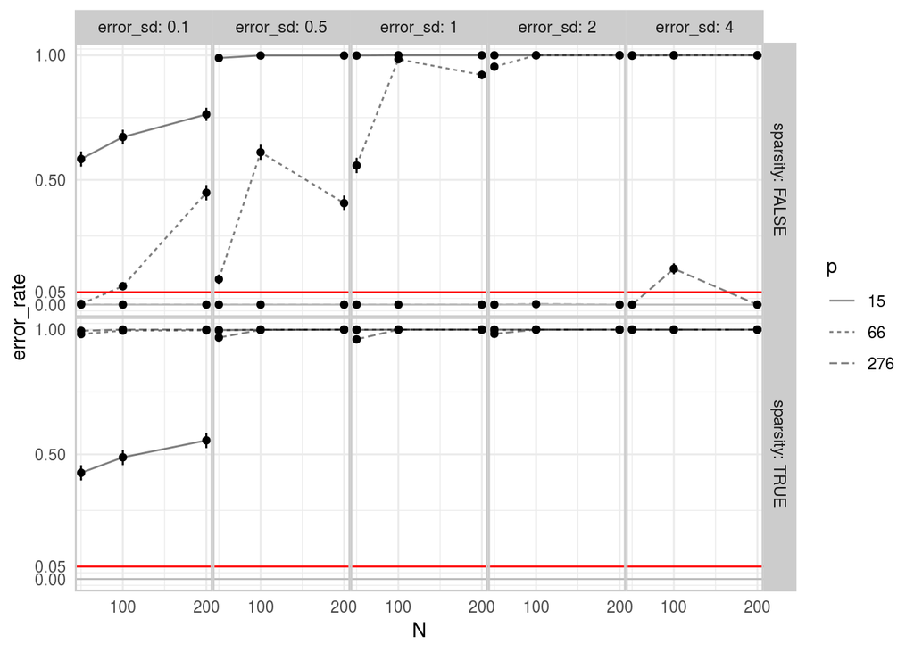

```r
get_individual_vector <- function(popvec, sd = 1){
  ivec <- rnorm(length(popvec), mean = popvec, sd = sd)
  return(ivec)
}
get_popvec <- function(veclen, n_pop, mean = 0, sd = 2){
  popvecs <- lapply(1:n_pop, function(i) {
    rnorm(n = veclen, mean = mean, sd = sd)
  })
  return(popvecs)
}
draw_data <- function(N, p, level = 1, error_sd = 1, es_sd = 2, es_mean = 0){
  if (!all(level %in% c(1,2))) {
    stop('Level not either 1 or 2')
  } else if(level == 1){
    popvec <- get_popvec(veclen = p, n_pop = 1, mean = es_mean, sd = es_sd)
    ivecs <- lapply(1:N, function(i){
      get_individual_vector(popvec = popvec[[1]], sd = error_sd)
    })
  } else if(level == 2) {
    popvecs <- get_popvec(veclen = p, n_pop = N, mean = es_mean, sd = es_sd)
    ivecs <- lapply(popvecs, function(popvec){
      get_individual_vector(popvec = popvec, sd = error_sd)
    })
  }
  return(ivecs)
}
calc_sim <- function(vec1, vec2){
  vec1_sig <- sign(vec1 * (abs(vec1) > 2))
  vec2_sig <- sign(vec2 * (abs(vec2) > 2))
  similarties <- (vec1_sig == vec2_sig) & (vec1_sig != 0) & (vec2_sig != 0)
  return(sum(similarties))
}
similarity_matrix <- function(ivecs, sparsity = T){
  N <- length(ivecs)
  simmat <- diag(N)
  for(i in 1:(N-1)){
    for(j in (i+1):N){
      asimil <- calc_sim(ivecs[[i]], ivecs[[j]])
      simmat[i,j] <- asimil
      simmat[j,i] <- asimil
    }
  }
  if(sparsity){
    min_sim <- min(simmat[upper.tri(simmat)])
    simmat <- simmat - min_sim
  }
  diag(simmat) <- 0
  return(simmat)
}

count_simil_coms <- function(N, p, sparsity = T, ...){
  data_list <- draw_data(N, p, ...)
  asimmat <- similarity_matrix(data_list, sparsity = sparsity)
  agraph <- igraph::graph_from_adjacency_matrix(asimmat, mode = 'undirected', weighted = T, diag = F)
  wtc <- igraph::walktrap.community(agraph)
  ncom <- length(wtc)
  return(ncom)
}

n.upper.tri <- Vectorize(function(size){
  size*(size-1)/2
})

replicates_simil_df <- expand.grid(N = c(50,100,200),
                                   p = n.upper.tri(c(6, 12, 24)),
                                   sparsity = c(T, F),
                                   error_sd = c(.1, .5, 1, 2, 4))

set.seed(1212223409)
replicates_simil_df$core <- sample(rep(1:3, each = 30), size = 90, replace = F)

library(parallel)
simulated_simil_rez <- parallel::mclapply(as.list(1:3), function(core){
  parset <- replicates_simil_df[replicates_simil_df$core == core,]
  somerez <- lapply(as.list(1:dim(parset)[1]), function(i){
    com_sizes <- replicate(1e3, expr = count_simil_coms(N = parset$N[i],
                                                        p = parset$p[i],
                                                        sparsity = parset$sparsity[i],
                                                        error_sd = parset$error_sd[i]))
    return(data.frame(
      N = parset$N[i],
      p = parset$p[i],
      sparsity = parset$sparsity[i],
      error_sd = parset$error_sd[i],
      size = com_sizes))
  })
  rezdf <- dplyr::bind_rows(somerez)
  return(rezdf)
}, mc.cores = 3)

simulated_simil_rez_df <- dplyr::bind_rows(simulated_simil_rez) %>%
  dplyr::mutate(single_comm_detected = size == 1 | size == N)

summary_simil_df <- dplyr::ungroup(
  dplyr::summarize(dplyr::group_by(simulated_simil_rez_df,
                                   N, p, sparsity, error_sd),
                   error_rate = mean(!single_comm_detected),
                   se = stderr.prop(error_rate, dplyr::n()),
                   ci.u = error_rate + 1.96*se,
                   ci.l = error_rate - 1.96*se))
library(ggplot2)
bordergray <- '#cccccc'
ggplot(dplyr::mutate(summary_simil_df, p = factor(p)), aes(x = N, y = error_rate)) +
  geom_errorbar(aes(ymin = ci.l, ymax = ci.u), width = 0) +
  geom_line(alpha = .5, aes(linetype = p)) +
  geom_hline(yintercept = .00, color = 'gray', size = .5) +
  geom_hline(yintercept = .05, color = 'red', size = .5) +
  geom_point() +
  facet_grid(sparsity ~ error_sd, labeller = label_both) +
  scale_x_continuous(breaks = nnodes) +
  scale_y_continuous(breaks = c(0, .05, .5, 1)) +
  theme_minimal() +
  theme(
        panel.border = element_rect(fill = NA, color = bordergray, size = 1, linetype = 1),
        strip.background = element_rect(fill=bordergray, color = bordergray, size = 1, linetype = 1),
        axis.line.x = element_line(color = NA, size = .5, linetype = 1),
        axis.line.y = element_line(color = NA, size = .5, linetype = 1),
panel.spacing = unit(0, units = 'in')) +
  coord_cartesian(y = c(0,1))
```